# Project 2

Seyoung Jung

2/9/2021

```r
library(AER)
library(tidyverse)
library(lubridate)
library(lmerTest)
library(scales)
library(kableExtra)
```

```r
data('Fatalities')
```

```r
summary(Fatalities)
```

```
##      state       year       spirits          unemp            income
##  al     :  7   1982:48   Min.   :0.790   Min.   : 2.400   Min.   : 9514
##  az     :  7   1983:48   1st Qu.:1.300   1st Qu.: 5.475   1st Qu.:12086
##  ar     :  7   1984:48   Median :1.670   Median : 7.000   Median :13763
##  ca     :  7   1985:48   Mean   :1.754   Mean   : 7.347   Mean   :13880
##  co     :  7   1986:48   3rd Qu.:2.013   3rd Qu.: 8.900   3rd Qu.:15175
##  ct     :  7   1987:48   Max.   :4.900   Max.   :18.000   Max.   :22193
##  (Other):294   1988:48
##      emppop         beertax           baptist            mormon
##  Min.   :42.99   Min.   :0.04331   Min.   : 0.0000   Min.   : 0.1000
##  1st Qu.:57.69   1st Qu.:0.20885   1st Qu.: 0.6268   1st Qu.: 0.2722
##  Median :61.36   Median :0.35259   Median : 1.7492   Median : 0.3931
##  Mean   :60.81   Mean   :0.51326   Mean   : 7.1569   Mean   : 2.8019
##  3rd Qu.:64.41   3rd Qu.:0.65157   3rd Qu.:13.1271   3rd Qu.: 0.6293
##  Max.   :71.27   Max.   :2.72076   Max.   :30.3557   Max.   :65.9165
##
##     drinkage          dry            youngdrivers         miles       breath
##  Min.   :18.00   Min.   : 0.00000   Min.   :0.07314   Min.   : 4576   no :181
##  1st Qu.:20.00   1st Qu.: 0.00000   1st Qu.:0.17037   1st Qu.: 7183   yes:155
##  Median :21.00   Median : 0.08681   Median :0.18539   Median : 7796
##  Mean   :20.46   Mean   : 4.26707   Mean   :0.18593   Mean   : 7891
##  3rd Qu.:21.00   3rd Qu.: 2.42481   3rd Qu.:0.20219   3rd Qu.: 8504
##  Max.   :21.00   Max.   :45.79210   Max.   :0.28163   Max.   :26148
##
##    jail     service        fatal            nfatal            sfatal
##  no  :241   no  :273   Min.   :  79.0   Min.   :  13.00   Min.   :  8.0
##  yes : 94   yes : 62   1st Qu.: 293.8   1st Qu.:  53.75   1st Qu.: 35.0
##  NA's:  1   NA's:  1   Median : 701.0   Median : 135.00   Median : 81.0
##                        Mean   : 928.7   Mean   : 182.58   Mean   :109.9
##                        3rd Qu.:1063.5   3rd Qu.: 212.00   3rd Qu.:131.0
##                        Max.   :5504.0   Max.   :1049.00   Max.   :603.0
##
##    fatal1517        nfatal1517      fatal1820       nfatal1820
##  Min.   :  3.00   Min.   : 0.00   Min.   :  7.0   Min.   :  0.00
##  1st Qu.: 25.75   1st Qu.: 4.00   1st Qu.: 38.0   1st Qu.: 11.00
##  Median : 49.00   Median :10.00   Median : 82.0   Median : 24.00
##  Mean   : 62.61   Mean   :12.26   Mean   :106.7   Mean   : 33.53
##  3rd Qu.: 77.00   3rd Qu.:15.25   3rd Qu.:130.2   3rd Qu.: 44.00
##  Max.   :318.00   Max.   :76.00   Max.   :601.0   Max.   :196.00
##
```

[output cut: 9 more lines]

```
##  Min.   :  21000   Min.   :  21000   Min.   :  30000   Min.   :  3993
##  1st Qu.:  71750   1st Qu.:  76962   1st Qu.: 103500   1st Qu.: 11692
##  Median : 163000   Median : 170982   Median : 241000   Median : 28484
##  Mean   : 230816   Mean   : 249090   Mean   : 336390   Mean   : 37101
##  3rd Qu.: 270500   3rd Qu.: 308311   3rd Qu.: 413000   3rd Qu.: 44140
##  Max.   :1172000   Max.   :1321004   Max.   :1892998   Max.   :241575
##
##     unempus         emppopus          gsp
##  Min.   :5.500   Min.   :57.80   Min.   :-0.123641
##  1st Qu.:6.200   1st Qu.:57.90   1st Qu.: 0.001182
##  Median :7.200   Median :60.10   Median : 0.032413
##  Mean   :7.529   Mean   :59.97   Mean   : 0.025313
##  3rd Qu.:9.600   3rd Qu.:61.50   3rd Qu.: 0.056501
##  Max.   :9.700   Max.   :62.30   Max.   : 0.142361
##
```

Observe the row(s) containing NA value in “jail” and/or “service”. One row (row #28) has NA in the two variables.

```r
Fatalities[which(is.na(Fatalities$jail) | is.na(Fatalities$service)), ]
```

```
##    state year spirits unemp   income   emppop    beertax baptist  mormon
## 28    ca 1988    1.72   5.3 18049.09 63.78366 0.08662175  1.7941 1.61578
##    drinkage dry youngdrivers   miles breath jail service fatal nfatal sfatal
## 28       21   0     0.148684 8531.99     no <NA>    <NA>  5390    936    541
##    fatal1517 nfatal1517 fatal1820 nfatal1820 fatal2124 nfatal2124  afatal
## 28       246         48       583        144       702        197 1246.71
##         pop pop1517 pop1820 pop2124 milestot unempus emppopus        gsp
## 28 28314028 1126998 1227989 1770001   241575     5.5     62.3 0.04902038
```

Observe the row which has the maximum value from the “miles” variable Notice the stark difference between the highest and the second highest average miles per driver

```r
Fatalities[order(-Fatalities$miles), ] %>% head(5)
```

```
##     state year spirits unemp   income   emppop    beertax baptist  mormon
## 171    ne 1984    1.45   4.4 13540.66 64.54623 0.34615386 0.71850 0.45456
## 336    wy 1988    1.55   6.3 13098.17 64.63768 0.04331088 3.00899 8.51208
## 335    wy 1987    1.59   8.6 12719.00 62.85714 0.04500000 2.90960 8.52302
## 334    wy 1986    1.70   9.0 13126.93 63.96648 0.04643963 2.81350 8.53397
## 333    wy 1985    1.88   7.1 13595.34 65.08380 0.04766949 2.72057 8.54494
##     drinkage     dry youngdrivers    miles breath jail service fatal nfatal
## 171     20.0 0.03738     0.192238 26148.27    yes   no      no   285     44
## 336     19.5 0.00000     0.131242 11812.12     no  yes      no   155     26
## 335     19.0 0.00000     0.149312 10953.05     no  yes      no   129     25
## 334     19.0 0.00000     0.168026 10619.33     no  yes      no   168     30
## 333     19.0 0.00000     0.191962 10611.01     no  yes      no   152     27
##     sfatal fatal1517 nfatal1517 fatal1820 nfatal1820 fatal2124 nfatal2124
## 171     23        28          6        27         11        37          9
## 336     18        10          1        23         11        19          5
## 335     18         8          2        19          6        12          4
## 334     19         8          1        25          7        25         11
## 333     22         8          3        20          2        24          7
##     afatal       pop  pop1517  pop1820   pop2124 milestot unempus emppopus
## 171 63.360 1605000.9 71000.03 83772.38 114999.70    41968     7.5     59.5
## 336 47.422  478999.7 21000.02 20999.96  30000.16     5658     5.5     62.3
## 335 35.500  490000.5 22000.02 22999.92  32999.67     5367     6.2     61.5
## 334 57.857  506999.9 23000.01 24000.00  34999.79     5384     7.0     60.7
## 333 52.345  508999.6 22000.02 24407.24  35000.22     5401     7.2     60.1
##             gsp
## 171  0.07834975
## 336 -0.01702319
## 335 -0.12364147
## 334 -0.10997585
## 333 -0.01212608
```

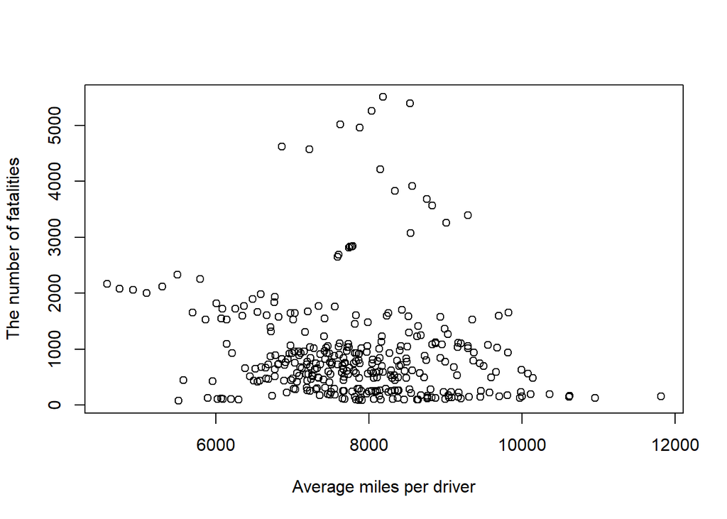

```r
plot(Fatalities$miles[-171], Fatalities$fatal[-171], xlab = 'Average miles per driver', ylab = 'The number of fatalities' )
```

[figure not shown]

```r
plot(Fatalities$miles[-171], Fatalities$frate[-171], xlab = 'Average miles per driver', ylab = 'Fatality rate' )
```

Check whether the other rows of California have data on “jail” and “service”. The other rows have “no”s in the jail and service columns.

```r
Fatalities[which(Fatalities$state=="ca"), ]
```

```
##    state year spirits unemp   income   emppop    beertax baptist  mormon
## 22    ca 1982    2.21   9.9 15797.14 59.51593 0.10739857  1.7231 1.67854
## 23    ca 1983    2.15   9.7 15970.18 59.25233 0.10321102  1.7347 1.66792
## 24    ca 1984    2.07   7.8 16590.11 60.69826 0.09890110  1.7464 1.65736
## 25    ca 1985    1.97   7.2 16985.17 61.33171 0.09533899  1.7582 1.64687
## 26    ca 1986    1.85   6.7 17356.04 62.00847 0.09287926  1.7701 1.63644
## 27    ca 1987    1.78   5.8 17846.00 63.07430 0.09000000  1.7821 1.62608
## 28    ca 1988    1.72   5.3 18049.09 63.78366 0.08662175  1.7941 1.61578
##    drinkage dry youngdrivers    miles breath jail service fatal nfatal sfatal
## 22       21   0     0.190196 6858.677     no   no      no  4615    944    553
## 23       21   0     0.183569 7216.292     no   no      no  4573    856    487
## 24       21   0     0.174131 7619.176     no   no      no  5020    957    559
## 25       21   0     0.167896 7874.067     no   no      no  4960    887    499
## 26       21   0     0.164371 8034.910     no   no      no  5253    880    510
## 27       21   0     0.160682 8180.633     no   no      no  5504    944    531
```

[output cut: 17 more lines]

Convert the “state”, “year”, “drinkage” into a factor variable

```r
Fatalities$drinkage = round(Fatalities$drinkage)
Fatalities$drinkage = as.factor(Fatalities$drinkage)
```

Correlation between “fatal” and the other non-categorical variables

```r
cor(Fatalities$fatal, Fatalities[, -which(sapply(Fatalities, class)=="factor")])
```

```
##          spirits      unemp    income     emppop    beertax   baptist
## [1,] -0.09308419 0.08813354 0.2396495 -0.1759576 0.05015268 0.1601994
##          mormon        dry youngdrivers      miles fatal   nfatal    sfatal
## [1,] -0.1502635 0.07081661   -0.1666919 -0.1214714     1 0.980256 0.9751958
##      fatal1517 nfatal1517 fatal1820 nfatal1820 fatal2124 nfatal2124   afatal
## [1,] 0.9705922   0.914173 0.9879878  0.9374014 0.9892364  0.9612318 0.937047
##            pop   pop1517   pop1820   pop2124  milestot    unempus   emppopus
## [1,] 0.9486741 0.9352757 0.9412835 0.9454599 0.9764374 -0.0296119 0.03118773
##            gsp
## [1,] 0.1256909
```

Create a new variable “frate” which is the total number of fatalities over the population of the state. Correlation between “frate” and the other non-categorical variables Some variables (e.g. income, beertax, baptist, miles, and youngdrivers) have relatively high correlations with “frate”.

```r
Fatalities$frate = Fatalities$fatal/Fatalities$pop

cor(Fatalities$frate, Fatalities[, -which(sapply(Fatalities, class)=="factor")])
```

```
##          spirits     unemp     income     emppop   beertax   baptist     mormon
## [1,] -0.06477855 0.1753446 -0.4988107 -0.1629708 0.3055533 0.4400984 0.08429171
##            dry youngdrivers     miles       fatal    nfatal     sfatal
## [1,] 0.1266582    0.2344221 0.3968298 -0.05370062 -0.100225 -0.1194522
##        fatal1517  nfatal1517   fatal1820 nfatal1820  fatal2124 nfatal2124
## [1,] -0.08869381 -0.06451125 -0.08113926 -0.1430495 -0.0627601 -0.1421332
##            afatal        pop    pop1517    pop1820    pop2124   milestot
## [1,] -0.008916801 -0.2681005 -0.2790974 -0.2739728 -0.2659518 -0.1922844
##           unempus   emppopus        gsp frate
## [1,] -0.006507014 0.01284845 -0.1818253     1
```

```r
#summary(glm(breath~frate,data=Fatalities,family=binomial))$coefficients # breath vs. frate
#summary(glm(jail~frate,data=Fatalities,family=binomial))$coefficients # jail vs. frate
#summary(glm(service~frate,data=Fatalities,family=binomial))$coefficients # service vs. frate

#summary(glm(breath~unemp,data=Fatalities,family=binomial))$coefficients # breath vs. unemp
#summary(glm(jail~unemp,data=Fatalities,family=binomial))$coefficients # jail vs. unemp
#summary(glm(service~unemp,data=Fatalities,family=binomial))$coefficients # service vs. unemp

#summary(glm(breath~miles,data=Fatalities,family=binomial))$coefficients # breath vs. miles
#summary(glm(jail~miles,data=Fatalities,family=binomial))$coefficients # jail vs. miles
#summary(glm(service~miles,data=Fatalities,family=binomial))$coefficients # service vs. miles

#summary(glm(breath~youngdrivers,data=Fatalities,family=binomial))$coefficients # breath vs. youngdrivers
#summary(glm(jail~youngdrivers,data=Fatalities,family=binomial))$coefficients # jail vs. youngdrivers
#summary(glm(service~youngdrivers,data=Fatalities,family=binomial))$coefficients # service vs. youngdrivers

#summary(glm(breath~beertax,data=Fatalities,family=binomial))$coefficients # breath vs. beertax
#summary(glm(jail~beertax,data=Fatalities,family=binomial))$coefficients # jail vs. beertax
#summary(glm(service~beertax,data=Fatalities,family=binomial))$coefficients # service vs. beertax

#summary(glm(breath~income,data=Fatalities,family=binomial))$coefficients # breath vs. income
#summary(glm(jail~income,data=Fatalities,family=binomial))$coefficients # jail vs. income
#summary(glm(service~income,data=Fatalities,family=binomial))$coefficients # service vs. income
```

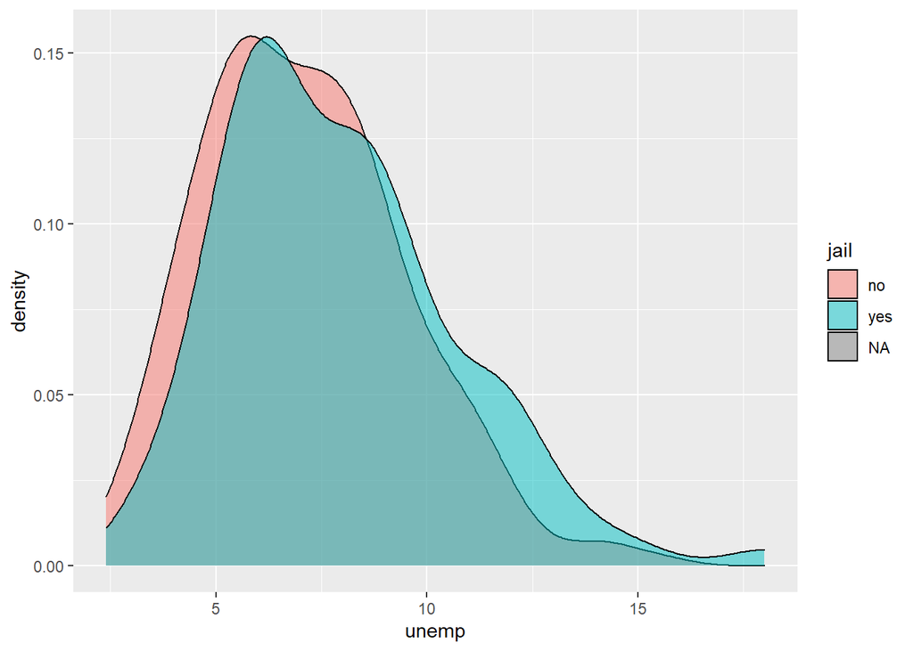

```r
# explore  relationships between jail and unemployment
ggplot(data=Fatalities, aes(unemp, fill = jail)) +
          geom_density( alpha = 0.5 )
```

unemployment does not seem to strongly impact the propensity of being assigned to treatment (jail = yes) or control (jail = no) group.

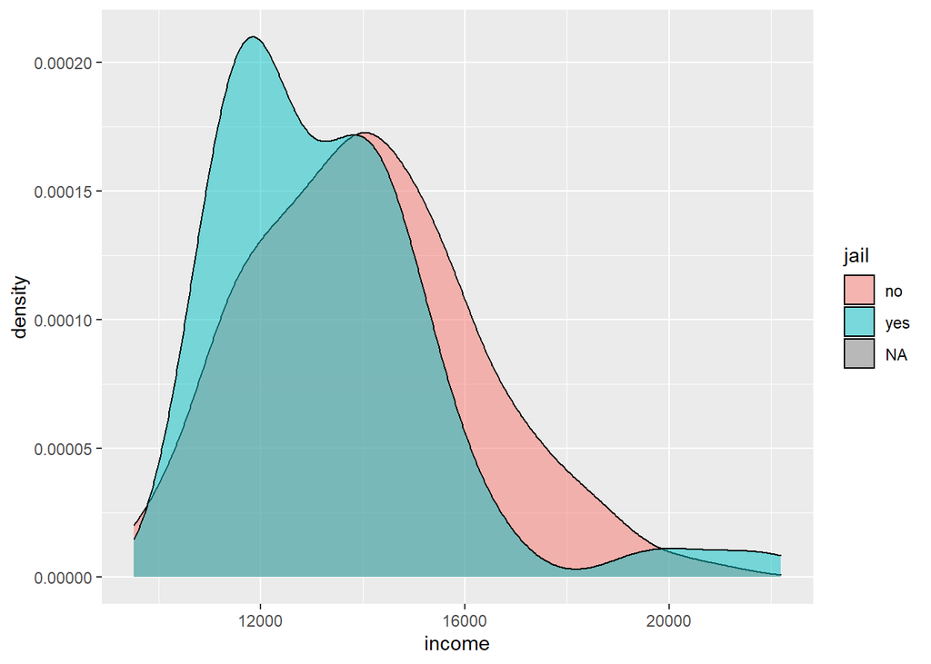

```r
# explore relationships between jail and income
ggplot(data=Fatalities, aes(income, fill = jail)) +
          geom_density( alpha = 0.5 )
```

It seems that income impacts the propensity of being assigned to treatment (jail = yes) or control (jail = no) group. Therefore income should be included in the selection model.

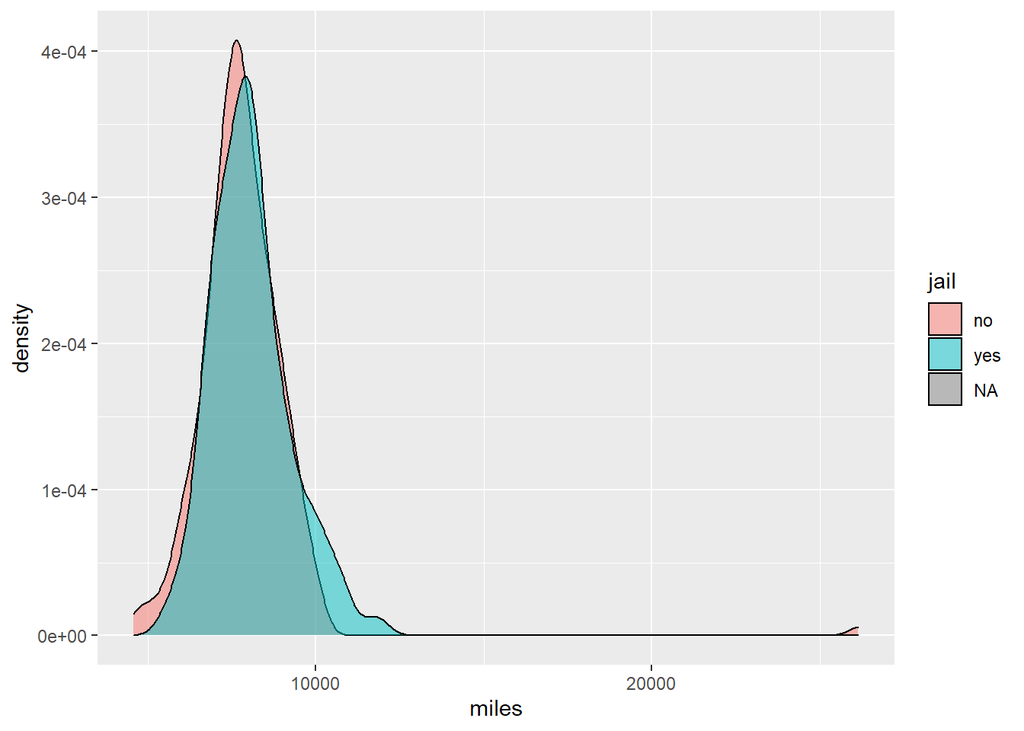

```r
# explore relationships between jail and fatalities
ggplot(data=Fatalities, aes(miles, fill = jail)) +
          geom_density( alpha = 0.5 )
```

mileage driven per person does not seem to strongly impact the propensity of being assigned to treatment (jail = yes) or control (jail = no) group.

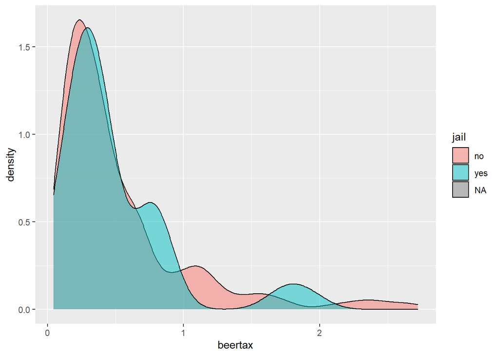

```r
# explore relationships between jail and beertax
ggplot(data=Fatalities, aes(beertax, fill = jail)) +
          geom_density( alpha = 0.5 )
```

beertax does not seem to strongly impact the propensity of being assigned to treatment (jail = yes) or control (jail = no) group.

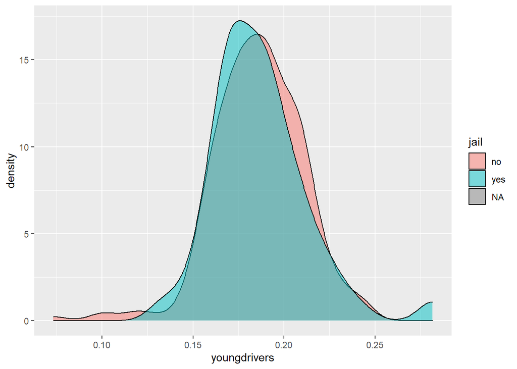

```r
# explore relationships between jail and youngdrivers
ggplot(data=Fatalities, aes(youngdrivers, fill = jail)) +
          geom_density( alpha = 0.5 )
```

percent of young drivers does not seem to strongly impact the propensity of being assigned to treatment (jail = yes) or control (jail = no) group.

```r
# Adpated from http://www.sthda.com/english/wiki/scatter-plot-matrices-r-base-graphs
my_cols <- c("#00AFBB", "#FC4E07")

# Correlation panel
panel.cor <- function(x, y){
    usr <- par("usr"); on.exit(par(usr))
    par(usr = c(0, 1, 0, 1))
    r <- cor(x, y)
    txt <- paste0("r = ", round(r, digits = 2))
    text(0.5, 0.5, txt, cex = 3*abs(r) )
}

# Customize upper panel
upper.panel<-function(x, y){
  points(x,y, pch = 19, col = alpha( my_cols[Fatalities$jail], 0.3 ) )
}
```

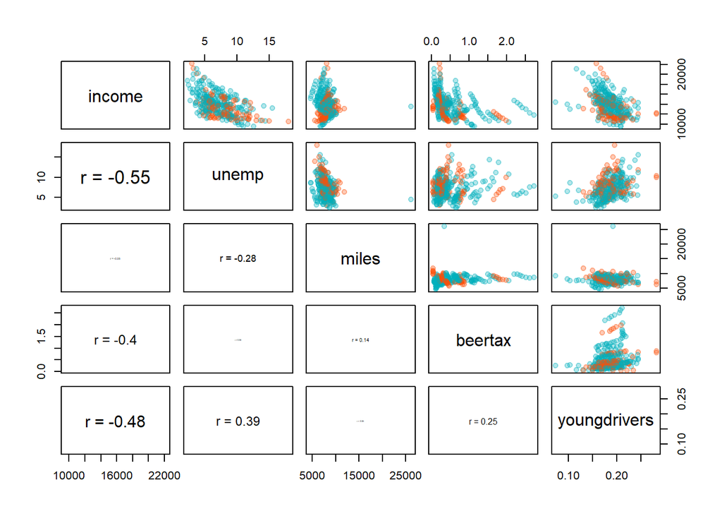

```r
pairs( Fatalities[, c('income', 'unemp', 'miles', 'beertax', 'youngdrivers') ],
       upper.panel = upper.panel,
       lower.panel = panel.cor )
```

========================================================================================== Model Building (Seyoung Jung) ==========================================================================================

```r
 cor(Fatalities$frate, Fatalities[, -which(sapply(Fatalities, class)=="factor")])
```

```
##          spirits     unemp     income     emppop   beertax   baptist     mormon
## [1,] -0.06477855 0.1753446 -0.4988107 -0.1629708 0.3055533 0.4400984 0.08429171
##            dry youngdrivers     miles       fatal    nfatal     sfatal
## [1,] 0.1266582    0.2344221 0.3968298 -0.05370062 -0.100225 -0.1194522
##        fatal1517  nfatal1517   fatal1820 nfatal1820  fatal2124 nfatal2124
## [1,] -0.08869381 -0.06451125 -0.08113926 -0.1430495 -0.0627601 -0.1421332
##            afatal        pop    pop1517    pop1820    pop2124   milestot
## [1,] -0.008916801 -0.2681005 -0.2790974 -0.2739728 -0.2659518 -0.1922844
##           unempus   emppopus        gsp frate
## [1,] -0.006507014 0.01284845 -0.1818253     1
```

Independent variables chosen based on the degree of correlation with “frate”

We start by building a tentative outcome model without the use of propensity scores.

## Model 1 (treatment (jail = yes) and control (jail = no))

```r
summary( lmer(frate ~ jail + rescale(unemp) + rescale(income) + rescale(beertax) + rescale(youngdrivers) +  rescale(miles) + (1|state), data=Fatalities) )$coef %>% round(.,3) %>%  kable() %>% kable_styling()
```

|  | Estimate | Std. Error | df | t value | Pr(>\|t\|) |
| --- | --- | --- | --- | --- | --- |
| (Intercept) | 0 | 0 | 85.809 | 9.624 | 0.000 |
| jailyes | 0 | 0 | 1751.196 | 0.424 | 0.671 |
| rescale(unemp) | 0 | 0 | 656.168 | -4.884 | 0.000 |
| rescale(income) | 0 | 0 | 1285.604 | 0.116 | 0.908 |
| rescale(beertax) | 0 | 0 | 15.167 | -0.594 | 0.561 |
| rescale(youngdrivers) | 0 | 0 | 186.386 | 5.104 | 0.000 |
| rescale(miles) | 0 | 0 | 174.624 | 1.374 | 0.171 |

We found a non-significant treatment effect, as the factor level jailyes is not statistically significant at p = 0.05. However, the covariates `unemp` and `youngdrivers` are statistically significant at p < 0.001.

Based on our exploratory data analysis and group discussion, we assume that the variables `unemp`, `income`, `beertax`, `youngdrivers` and `miles` have an influence on the assignment to either the control (jail = no) or the treatment (jail = yes) group.

Next we performed a balance analysis, trying to assess the degree of bias during assignment to treatment and control groups, before the use of propensity scores.

```r
# balance analysis before estimating propensity scores
summary( lm(miles ~ jail, data = Fatalities) )$coefficients %>% round(., 3) %>% kable() %>% kable_styling()
```

|  | Estimate | Std. Error | t value | Pr(>\|t\|) |
| --- | --- | --- | --- | --- |
| (Intercept) | 7822.881 | 95.069 | 82.286 | 0.000 |
| jailyes | 235.065 | 179.472 | 1.310 | 0.191 |

```r
summary( lm(income ~ jail, data = Fatalities) ) $coefficients %>% round(., 3)%>% kable() %>% kable_styling()
```

|  | Estimate | Std. Error | t value | Pr(>\|t\|) |
| --- | --- | --- | --- | --- |
| (Intercept) | 14078.754 | 143.164 | 98.340 | 0.000 |
| jailyes | -752.018 | 270.266 | -2.783 | 0.006 |

```r
summary( lm(beertax ~ jail, data = Fatalities) )$coefficients %>% round(., 3)%>% kable() %>% kable_styling()
```

|  | Estimate | Std. Error | t value | Pr(>\|t\|) |
| --- | --- | --- | --- | --- |
| (Intercept) | 0.526 | 0.031 | 17.078 | 0.000 |
| jailyes | -0.042 | 0.058 | -0.716 | 0.475 |

```r
summary( lm(youngdrivers ~ jail, data = Fatalities) )$coefficients %>% round(., 3) %>% kable() %>% kable_styling()
```

|  | Estimate | Std. Error | t value | Pr(>\|t\|) |
| --- | --- | --- | --- | --- |
| (Intercept) | 0.186 | 0.002 | 116.054 | 0.000 |
| jailyes | 0.001 | 0.003 | 0.206 | 0.837 |

```r
summary( lm(unemp ~ jail, data = Fatalities) )$coefficients %>% round(., 3) %>% kable() %>% kable_styling()
```

|  | Estimate | Std. Error | t value | Pr(>\|t\|) |
| --- | --- | --- | --- | --- |
| (Intercept) | 7.124 | 0.162 | 44.031 | 0.000 |
| jailyes | 0.814 | 0.305 | 2.664 | 0.008 |

```r
mod1 = glm(jail ~ unemp + income + beertax + youngdrivers + miles,
           family="binomial", data=Fatalities)
summary(mod1)$coef %>% round(., 3) %>% kable() %>% kable_styling()
```

|  | Estimate | Std. Error | z value | Pr(>\|z\|) |
| --- | --- | --- | --- | --- |
| (Intercept) | 0.856 | 2.313 | 0.370 | 0.711 |
| unemp | 0.107 | 0.065 | 1.637 | 0.102 |
| income | 0.000 | 0.000 | -1.997 | 0.046 |
| beertax | -0.519 | 0.319 | -1.625 | 0.104 |
| youngdrivers | -6.648 | 5.666 | -1.173 | 0.241 |
| miles | 0.000 | 0.000 | 1.546 | 0.122 |

```r
prob1 = mod1$fitted.values
pscore1 = ifelse( Fatalities$jail == "yes", prob1,(1-prob1) )
weight1 = 1/pscore1

mod1_new = lmer(frate ~ jail + rescale(unemp) + rescale(income) + rescale(beertax) + rescale(youngdrivers) + rescale(miles) + (1|state), data=Fatalities, weights=weight1)

summary(mod1_new)$coef %>% round(., 3) %>% kable() %>% kable_styling()
```

|  | Estimate | Std. Error | df | t value | Pr(>\|t\|) |
| --- | --- | --- | --- | --- | --- |
| (Intercept) | 0 | 0 | 263.219 | 9.196 | 0.000 |
| jailyes | 0 | 0 | 327.378 | 0.295 | 0.768 |
| rescale(unemp) | 0 | 0 | 315.168 | -4.725 | 0.000 |
| rescale(income) | 0 | 0 | 325.875 | 0.623 | 0.534 |
| rescale(beertax) | 0 | 0 | 134.025 | -0.275 | 0.784 |
| rescale(youngdrivers) | 0 | 0 | 282.873 | 5.833 | 0.000 |
| rescale(miles) | 0 | 0 | 286.475 | 1.699 | 0.090 |

We used logistic regression to determine the probability of treatment/control assignment, given the 5 chose covariates mentioned earlier. The estimated probablities were then converted to propensity scores, whose inverse are included as weights in the linear mixed model. After applying propensity score weighting, we still do not found significant treatment effect, as the factor level jailyes is not statistically significant at p = 0.05. Again, the covariates `unemp` and `youngdrivers` are statistically significant at p < 0.001.

```r
# balance analysis after propensity score estimation
summary( lm(miles ~ jail, weight = weight1, data = Fatalities) )$coefficients %>% round(., 3) %>% kable() %>% kable_styling()
```

|  | Estimate | Std. Error | t value | Pr(>\|t\|) |
| --- | --- | --- | --- | --- |
| (Intercept) | 7831.904 | 101.383 | 77.251 | 0.00 |
| jailyes | 168.674 | 143.402 | 1.176 | 0.24 |

```r
summary( lm(income ~ jail, weight = weight1,data = Fatalities) )$coefficients %>% round(., 3) %>% kable() %>% kable_styling()
```

|  | Estimate | Std. Error | t value | Pr(>\|t\|) |
| --- | --- | --- | --- | --- |
| (Intercept) | 13898.362 | 195.057 | 71.253 | 0.000 |
| jailyes | 35.075 | 275.899 | 0.127 | 0.899 |

```r
summary( lm(beertax ~ jail, weight = weight1,data = Fatalities) )$coefficients %>% round(., 3) %>% kable() %>% kable_styling()
```

|  | Estimate | Std. Error | t value | Pr(>\|t\|) |
| --- | --- | --- | --- | --- |
| (Intercept) | 0.520 | 0.036 | 14.379 | 0.000 |
| jailyes | -0.002 | 0.051 | -0.035 | 0.972 |

```r
summary( lm(youngdrivers ~ jail, weight = weight1, data = Fatalities) )$coefficients %>% round(., 3) %>% kable() %>% kable_styling()
```

|  | Estimate | Std. Error | t value | Pr(>\|t\|) |
| --- | --- | --- | --- | --- |
| (Intercept) | 0.186 | 0.002 | 96.597 | 0.00 |
| jailyes | 0.000 | 0.003 | -0.151 | 0.88 |

```r
summary( lm(unemp ~ jail, weight = weight1, data = Fatalities) )$coefficients %>% round(., 3) %>% kable() %>% kable_styling()
```

|  | Estimate | Std. Error | t value | Pr(>\|t\|) |
| --- | --- | --- | --- | --- |
| (Intercept) | 7.255 | 0.197 | 36.915 | 0.000 |
| jailyes | 0.030 | 0.278 | 0.107 | 0.915 |

The selection biases by `income` and `unemp` are reduced much after propensity score weighting.

## Model 2 (control: breath)

```r
summary( lmer(frate ~ breath + rescale(unemp) + rescale(income) + rescale(beertax) + rescale(youngdrivers) +  rescale(miles) + (1|state), data=Fatalities) )$coef %>% round(.,3) %>%  kable() %>% kable_styling()
```

|  | Estimate | Std. Error | df | t value | Pr(>\|t\|) |
| --- | --- | --- | --- | --- | --- |
| (Intercept) | 0 | 0 | 73.086 | 9.809 | 0.000 |
| breathyes | 0 | 0 | 713.993 | -1.974 | 0.049 |
| rescale(unemp) | 0 | 0 | 609.108 | -4.941 | 0.000 |
| rescale(income) | 0 | 0 | 1205.402 | 0.339 | 0.735 |
| rescale(beertax) | 0 | 0 | 13.102 | -0.485 | 0.636 |
| rescale(youngdrivers) | 0 | 0 | 164.786 | 5.233 | 0.000 |
| rescale(miles) | 0 | 0 | 153.814 | 1.434 | 0.154 |

We found a marginally treatment effect, as the factor level breathyes is statistically significant at p = 0.05. Interestingly, the covariates `unemp` and `youngdrivers` are statistically significant at p < 0.001.

Likewise, we performed a balance analysis before the use of propensity scores.

```r
# balance analysis before estimating propensity scores
summary( lm(miles ~ breath, data = Fatalities) )$coefficients %>% round(., 3) %>% kable() %>% kable_styling()
```

|  | Estimate | Std. Error | t value | Pr(>\|t\|) |
| --- | --- | --- | --- | --- |
| (Intercept) | 8028.147 | 109.29 | 73.457 | 0.000 |
| breathyes | -297.833 | 160.91 | -1.851 | 0.065 |

```r
summary( lm(income ~ breath, data = Fatalities) ) $coefficients %>% round(., 3)%>% kable() %>% kable_styling()
```

|  | Estimate | Std. Error | t value | Pr(>\|t\|) |
| --- | --- | --- | --- | --- |
| (Intercept) | 13656.641 | 166.748 | 81.900 | 0.000 |
| breathyes | 484.585 | 245.508 | 1.974 | 0.049 |

```r
summary( lm(beertax ~ breath, data = Fatalities) )$coefficients %>% round(., 3)%>% kable() %>% kable_styling()
```

|  | Estimate | Std. Error | t value | Pr(>\|t\|) |
| --- | --- | --- | --- | --- |
| (Intercept) | 0.560 | 0.035 | 15.823 | 0.000 |
| breathyes | -0.101 | 0.052 | -1.934 | 0.054 |

```r
summary( lm(youngdrivers ~ breath, data = Fatalities) )$coefficients %>% round(., 3) %>% kable() %>% kable_styling()
```

|  | Estimate | Std. Error | t value | Pr(>\|t\|) |
| --- | --- | --- | --- | --- |
| (Intercept) | 0.187 | 0.002 | 100.956 | 0.00 |
| breathyes | -0.002 | 0.003 | -0.691 | 0.49 |

```r
summary( lm(unemp ~ breath, data = Fatalities) )$coefficients %>% round(., 3) %>% kable() %>% kable_styling()
```

|  | Estimate | Std. Error | t value | Pr(>\|t\|) |
| --- | --- | --- | --- | --- |
| (Intercept) | 7.738 | 0.186 | 41.618 | 0.000 |
| breathyes | -0.848 | 0.274 | -3.099 | 0.002 |

This time it turns out that covariate `unemp` shows strong imbalance between treatment (jail = yes) and control (jail = no ) groups (p < 0.01), and covariate `income` shows a marginal significant imbalance (p < 0.05). Although not significant, the significance levels of covariates `miles` and `beertax` are close to p = 0.05 level, also suggesting potential selection bias. These should be addressed using propensity scores.

```r
mod2 = glm(breath ~ unemp + income + beertax + youngdrivers + miles,
           family="binomial", data=Fatalities)
summary(mod2)$coef %>% round(., 3) %>% kable() %>% kable_styling()
```

|  | Estimate | Std. Error | z value | Pr(>\|z\|) |
| --- | --- | --- | --- | --- |
| (Intercept) | 4.977 | 2.334 | 2.132 | 0.033 |
| unemp | -0.242 | 0.065 | -3.719 | 0.000 |
| income | 0.000 | 0.000 | -1.174 | 0.240 |
| beertax | -0.476 | 0.287 | -1.659 | 0.097 |
| youngdrivers | 3.439 | 5.299 | 0.649 | 0.516 |
| miles | 0.000 | 0.000 | -2.680 | 0.007 |

We found that covariate `unemp` significantly impact the assignment to treatment or control group at p < 0.001, and covariate `miles` significantly impact the assignment to treatment or control group at p < 0.0. Again, all 5 variables are included in the selection model regardless of their significance level.

```r
prob2 = mod2$fitted.values
pscore2 = ifelse(Fatalities$breath == "yes", prob2,(1-prob2))
weight2 = 1/pscore2
mod2_new = lmer( frate ~ breath+rescale(unemp)+rescale(income)+rescale(beertax)+rescale(youngdrivers)+rescale(miles)+(1|state),data=Fatalities, weights=weight2)
summary(mod2_new)$coef %>% round(., 3) %>% kable() %>% kable_styling()
```

|  | Estimate | Std. Error | df | t value | Pr(>\|t\|) |
| --- | --- | --- | --- | --- | --- |
| (Intercept) | 0 | 0 | 256.562 | 10.613 | 0.000 |
| breathyes | 0 | 0 | 316.068 | -1.754 | 0.080 |
| rescale(unemp) | 0 | 0 | 312.832 | -5.283 | 0.000 |
| rescale(income) | 0 | 0 | 328.542 | 0.478 | 0.633 |
| rescale(beertax) | 0 | 0 | 146.914 | -0.191 | 0.849 |
| rescale(youngdrivers) | 0 | 0 | 290.075 | 4.757 | 0.000 |
| rescale(miles) | 0 | 0 | 289.267 | 1.282 | 0.201 |

Likewise, after applying propensity score weighting, we still do not found significant treatment effect, as the factor level breathyes is not statistically significant at p = 0.05. Nevertheless, it is significant at p < 0.1, indicating potential effects that needs further investigation. Again, the covariates unemp and youngdrivers are statistically significant at p < 0.001.

```r
# balance analysis after propensity score estimation
summary( lm(miles ~ breath, weight = weight2, data = Fatalities) )$coefficients %>% round(., 3) %>% kable() %>% kable_styling()
```

[output not shown]

```r
summary( lm(income ~ breath, weight = weight2,data = Fatalities) )$coefficients %>% round(., 3) %>% kable() %>% kable_styling()
```

|  | Estimate | Std. Error | t value | Pr(>\|t\|) |
| --- | --- | --- | --- | --- |
| (Intercept) | 13878.499 | 181.321 | 76.541 | 0.000 |
| breathyes | -139.979 | 231.480 | -0.605 | 0.546 |

```r
summary( lm(beertax ~ breath, weight = weight2,data = Fatalities) )$coefficients %>% round(., 3) %>% kable() %>% kable_styling()
```

|  | Estimate | Std. Error | t value | Pr(>\|t\|) |
| --- | --- | --- | --- | --- |
| (Intercept) | 0.511 | 0.034 | 15.133 | 0.000 |
| breathyes | -0.077 | 0.043 | -1.778 | 0.076 |

```r
summary( lm(youngdrivers ~ breath, weight = weight2, data = Fatalities) )$coefficients %>% round(., 3) %>% kable() %>% kable_styling()
```

|  | Estimate | Std. Error | t value | Pr(>\|t\|) |
| --- | --- | --- | --- | --- |
| (Intercept) | 0.186 | 0.002 | 96.766 | 0.000 |
| breathyes | 0.002 | 0.002 | 0.947 | 0.345 |

```r
summary( lm(unemp ~ breath, weight = weight2, data = Fatalities) )$coefficients %>% round(., 3) %>% kable() %>% kable_styling()
```

|  | Estimate | Std. Error | t value | Pr(>\|t\|) |
| --- | --- | --- | --- | --- |
| (Intercept) | 7.437 | 0.244 | 30.505 | 0.000 |
| breathyes | -0.993 | 0.311 | -3.190 | 0.002 |

Model 3 (control: service)

```r
mod3 = glm(service ~ rescale(unemp)+rescale(income)+rescale(beertax)+rescale(youngdrivers)+rescale(miles),
           family="binomial", data=Fatalities)
prob3 = mod3$fitted.values
pscore3 = ifelse(Fatalities$service == "yes", prob3,(1-prob3))
weight3 = 1/pscore3
mod3_new = lmer(frate~service+rescale(unemp)+rescale(income)+rescale(beertax)+rescale(youngdrivers)+
                  rescale(miles)+(1|state),data=Fatalities, weights=weight3)
summary(mod3_new)
```

```
## Linear mixed model fit by REML. t-tests use Satterthwaite's method [
## lmerModLmerTest]
## Formula:
## frate ~ service + rescale(unemp) + rescale(income) + rescale(beertax) +
##     rescale(youngdrivers) + rescale(miles) + (1 | state)
##    Data: Fatalities
## Weights: weight3
##
## REML criterion at convergence: -6004.9
##
## Scaled residuals:
##     Min      1Q  Median      3Q     Max
## -3.7849 -0.4023 -0.0294  0.4119  4.2231
##
## Random effects:
##  Groups   Name        Variance  Std.Dev.
##  state    (Intercept) 2.945e-09 5.427e-05
##  Residual             5.690e-10 2.385e-05
## Number of obs: 335, groups:  state, 48
##
## Fixed effects:
##                         Estimate Std. Error         df t value Pr(>|t|)
## (Intercept)            1.798e-04  1.889e-05  2.750e+02   9.517  < 2e-16 ***
## serviceyes             2.310e-07  7.618e-06  3.280e+02   0.030   0.9758
## rescale(unemp)        -7.066e-05  1.529e-05  3.174e+02  -4.622 5.54e-06 ***
## rescale(income)        2.052e-06  2.534e-05  3.234e+02   0.081   0.9355
## rescale(beertax)       2.616e-05  3.304e-05  1.467e+02   0.792   0.4299
## rescale(youngdrivers)  6.151e-05  1.245e-05  2.893e+02   4.938 1.33e-06 ***
## rescale(miles)         5.236e-05  2.400e-05  2.912e+02   2.182   0.0299 *
## ---
## Signif. codes:  0 '***' 0.001 '**' 0.01 '*' 0.05 '.' 0.1 ' ' 1
##
## Correlation of Fixed Effects:
##             (Intr) srvcys rscl(nm) rscl(nc) rscl(b) rscl(y)
## serviceyes   0.016
## rescal(nmp) -0.586  0.011
## rescal(ncm) -0.750 -0.147  0.673
## rescl(brtx) -0.374 -0.107  0.097    0.190
## rscl(yngdr) -0.452  0.008 -0.104    0.235   -0.102
## rescal(mls) -0.270 -0.009  0.128   -0.078   -0.008   0.228
```

========================================================================================== Code used by TA in the discussion session ==========================================================================================

```r
dat = Fatalities[, c('fatal', 'beertax', 'jail', 'unemp', 'state', 'youngdrivers')]
dat = dat[!is.na(dat$jail), ]

model1 = lmer(fatal~beertax+jail+unemp+youngdrivers+(1|state),data=dat)
summary(model1)
```

```
## Linear mixed model fit by REML. t-tests use Satterthwaite's method [
## lmerModLmerTest]
## Formula: fatal ~ beertax + jail + unemp + youngdrivers + (1 | state)
##    Data: dat
##
## REML criterion at convergence: 4203.7
##
## Scaled residuals:
##     Min      1Q  Median      3Q     Max
## -4.5011 -0.4130 -0.0328  0.4002  5.6435
##
## Random effects:
##  Groups   Name        Variance Std.Dev.
##  state    (Intercept) 924593   961.56
##  Residual               7320    85.56
## Number of obs: 335, groups:  state, 48
##
## Fixed effects:
##              Estimate Std. Error      df t value Pr(>|t|)
## (Intercept)   1123.87     151.08   64.41   7.439 3.04e-10 ***
## beertax       -265.70      85.54  321.21  -3.106  0.00206 **
## jailyes        -18.68      31.94  289.08  -0.585  0.55908
## unemp          -30.59       3.61  285.96  -8.473 1.28e-15 ***
## youngdrivers   914.63     322.37  284.24   2.837  0.00488 **
## ---
## Signif. codes:  0 '***' 0.001 '**' 0.01 '*' 0.05 '.' 0.1 ' ' 1
##
## Correlation of Fixed Effects:
##             (Intr) beertx jailys unemp
## beertax     -0.203
## jailyes     -0.073 -0.114
## unemp        0.079 -0.157  0.121
## youngdrivrs -0.266 -0.134  0.066 -0.546
```

Can we say that jail cannot cause the reduction or increase of fatalities? We cannot get causal effect from an observational study directly because there exists selection bias

Balance analysis

```r
model2 = lm(unemp~jail, data=dat)
summary(model2)
```

```
##
## Call:
## lm(formula = unemp ~ jail, data = dat)
##
## Residuals:
##     Min      1Q  Median      3Q     Max
## -4.9383 -1.8245 -0.2245  1.5186 10.0617
##
## Coefficients:
##             Estimate Std. Error t value Pr(>|t|)
## (Intercept)   7.1245     0.1618  44.031  < 2e-16 ***
## jailyes       0.8138     0.3055   2.664  0.00809 **
## ---
## Signif. codes:  0 '***' 0.001 '**' 0.01 '*' 0.05 '.' 0.1 ' ' 1
##
## Residual standard error: 2.512 on 333 degrees of freedom
## Multiple R-squared:  0.02087,    Adjusted R-squared:  0.01793
## F-statistic: 7.098 on 1 and 333 DF,  p-value: 0.008091
```

To remove the selection bias, we can use propensity scores as weights in our model First, we need to build a selection model for estimating the propensity scores The propensity score is defined as the conditional probability given background variables

```r
Fatalities$service = relevel(Fatalities$service, ref="no")
models = glm(service ~ beertax+unemp+youngdrivers, family="binomial", data=Fatalities)
prob = models$fitted.values
pscore = ifelse(Fatalities$service == "yes", prob,(1-prob))
weight = 1/pscore

model_new = lmer(frate~beertax+service+unemp+youngdrivers+(1|state),data=Fatalities, weights=weight)
summary(model_new)
```

```
## Linear mixed model fit by REML. t-tests use Satterthwaite's method [
## lmerModLmerTest]
## Formula: frate ~ beertax + service + unemp + youngdrivers + (1 | state)
##    Data: Fatalities
## Weights: weight
##
## REML criterion at convergence: -6029.2
##
## Scaled residuals:
##     Min      1Q  Median      3Q     Max
## -3.8948 -0.3921 -0.0109  0.4130  4.0990
##
## Random effects:
##  Groups   Name        Variance  Std.Dev.
##  state    (Intercept) 3.099e-09 5.567e-05
##  Residual             5.819e-10 2.412e-05
## Number of obs: 335, groups:  state, 48
##
## Fixed effects:
##                Estimate Std. Error         df t value Pr(>|t|)
## (Intercept)   1.841e-04  1.318e-05  1.749e+02  13.972  < 2e-16 ***
## beertax       9.665e-06  1.246e-05  1.450e+02   0.776    0.439
## serviceyes    6.222e-07  7.704e-06  3.300e+02   0.081    0.936
## unemp        -5.010e-06  7.096e-07  2.983e+02  -7.060 1.17e-11 ***
## youngdrivers  2.777e-04  5.615e-05  2.938e+02   4.945 1.28e-06 ***
## ---
## Signif. codes:  0 '***' 0.001 '**' 0.01 '*' 0.05 '.' 0.1 ' ' 1
##
## Correlation of Fixed Effects:
##             (Intr) beertx srvcys unemp
## beertax     -0.323
## serviceyes  -0.181 -0.085
## unemp       -0.042 -0.042  0.161
## youngdrivrs -0.539 -0.172  0.051 -0.443
```

```r
anova(model_new)
```

```
## Type III Analysis of Variance Table with Satterthwaite's method
##                  Sum Sq    Mean Sq NumDF  DenDF F value    Pr(>F)
## beertax      3.5020e-10 3.5020e-10     1 145.03  0.6018    0.4391
## service      3.8000e-12 3.8000e-12     1 330.00  0.0065    0.9357
## unemp        2.9008e-08 2.9008e-08     1 298.25 49.8469 1.172e-11 ***
## youngdrivers 1.4230e-08 1.4230e-08     1 293.82 24.4532 1.283e-06 ***
## ---
## Signif. codes:  0 '***' 0.001 '**' 0.01 '*' 0.05 '.' 0.1 ' ' 1
```